# Risk Factor Analysis

## Outcome Variable

**Outcome Variable:** y_rate_haz

## Predictor Variables

**Intervention Variable:** fhtcm

**Adjustment Set:**

unadjusted

## Stratifying Variables

The analysis was stratified on these variable(s):

- agecat
- studyid
- country

## Data Summary

| agecat | studyid | country | fhtcm | n_cell | n |
| --- | --- | --- | --- | --- | --- |
| 0-3 months | COHORTS | GUATEMALA | >=167 cm | 25 | 180 |
| 0-3 months | COHORTS | GUATEMALA | <162 cm | 106 | 180 |
| 0-3 months | COHORTS | GUATEMALA | [162-167) cm | 49 | 180 |
| 0-3 months | Keneba | GAMBIA | >=167 cm | 631 | 965 |
| 0-3 months | Keneba | GAMBIA | <162 cm | 75 | 965 |
| 0-3 months | Keneba | GAMBIA | [162-167) cm | 259 | 965 |
| 0-3 months | PROBIT | BELARUS | >=167 cm | 10775 | 11502 |
| 0-3 months | PROBIT | BELARUS | <162 cm | 151 | 11502 |
| 0-3 months | PROBIT | BELARUS | [162-167) cm | 576 | 11502 |
| 0-3 months | SAS-CompFeed | INDIA | >=167 cm | 345 | 765 |
| 0-3 months | SAS-CompFeed | INDIA | <162 cm | 196 | 765 |
| 0-3 months | SAS-CompFeed | INDIA | [162-167) cm | 224 | 765 |
| 3-6 months | COHORTS | GUATEMALA | >=167 cm | 37 | 261 |
| 3-6 months | COHORTS | GUATEMALA | <162 cm | 148 | 261 |
| 3-6 months | COHORTS | GUATEMALA | [162-167) cm | 76 | 261 |
| 3-6 months | Keneba | GAMBIA | >=167 cm | 673 | 1037 |
| 3-6 months | Keneba | GAMBIA | <162 cm | 74 | 1037 |
| 3-6 months | Keneba | GAMBIA | [162-167) cm | 290 | 1037 |
| 3-6 months | PROBIT | BELARUS | >=167 cm | 9472 | 10103 |
| 3-6 months | PROBIT | BELARUS | <162 cm | 129 | 10103 |
| 3-6 months | PROBIT | BELARUS | [162-167) cm | 502 | 10103 |
| 3-6 months | SAS-CompFeed | INDIA | >=167 cm | 308 | 682 |
| 3-6 months | SAS-CompFeed | INDIA | <162 cm | 175 | 682 |
| 3-6 months | SAS-CompFeed | INDIA | [162-167) cm | 199 | 682 |
| 6-9 months | COHORTS | GUATEMALA | >=167 cm | 39 | 308 |
| 6-9 months | COHORTS | GUATEMALA | <162 cm | 186 | 308 |
| 6-9 months | COHORTS | GUATEMALA | [162-167) cm | 83 | 308 |
| 6-9 months | Keneba | GAMBIA | >=167 cm | 442 | 663 |
| 6-9 months | Keneba | GAMBIA | <162 cm | 53 | 663 |
| 6-9 months | Keneba | GAMBIA | [162-167) cm | 168 | 663 |

[output cut: 72 more lines]

The following strata were considered:

- agecat: 0-3 months, studyid: COHORTS, country: GUATEMALA
- agecat: 0-3 months, studyid: Keneba, country: GAMBIA
- agecat: 0-3 months, studyid: PROBIT, country: BELARUS
- agecat: 0-3 months, studyid: SAS-CompFeed, country: INDIA
- agecat: 12-15 months, studyid: COHORTS, country: GUATEMALA
- agecat: 12-15 months, studyid: Keneba, country: GAMBIA
- agecat: 12-15 months, studyid: PROBIT, country: BELARUS
- agecat: 12-15 months, studyid: SAS-CompFeed, country: INDIA
- agecat: 12-15 months, studyid: SAS-FoodSuppl, country: INDIA
- agecat: 15-18 months, studyid: COHORTS, country: GUATEMALA
- agecat: 15-18 months, studyid: Keneba, country: GAMBIA
- agecat: 15-18 months, studyid: PROBIT, country: BELARUS
- agecat: 15-18 months, studyid: SAS-CompFeed, country: INDIA
- agecat: 15-18 months, studyid: SAS-FoodSuppl, country: INDIA
- agecat: 18-21 months, studyid: COHORTS, country: GUATEMALA
- agecat: 18-21 months, studyid: Keneba, country: GAMBIA
- agecat: 18-21 months, studyid: PROBIT, country: BELARUS
- agecat: 21-24 months, studyid: COHORTS, country: GUATEMALA
- agecat: 21-24 months, studyid: Keneba, country: GAMBIA
- agecat: 21-24 months, studyid: PROBIT, country: BELARUS
- agecat: 3-6 months, studyid: COHORTS, country: GUATEMALA
- agecat: 3-6 months, studyid: Keneba, country: GAMBIA
- agecat: 3-6 months, studyid: PROBIT, country: BELARUS
- agecat: 3-6 months, studyid: SAS-CompFeed, country: INDIA
- agecat: 6-9 months, studyid: COHORTS, country: GUATEMALA
- agecat: 6-9 months, studyid: Keneba, country: GAMBIA
- agecat: 6-9 months, studyid: PROBIT, country: BELARUS
- agecat: 6-9 months, studyid: SAS-CompFeed, country: INDIA
- agecat: 6-9 months, studyid: SAS-FoodSuppl, country: INDIA
- agecat: 9-12 months, studyid: COHORTS, country: GUATEMALA
- agecat: 9-12 months, studyid: Keneba, country: GAMBIA
- agecat: 9-12 months, studyid: PROBIT, country: BELARUS
- agecat: 9-12 months, studyid: SAS-CompFeed, country: INDIA
- agecat: 9-12 months, studyid: SAS-FoodSuppl, country: INDIA

### Dropped Strata

Some strata were dropped due to rare outcomes:

- agecat: 15-18 months, studyid: PROBIT, country: BELARUS
- agecat: 18-21 months, studyid: PROBIT, country: BELARUS
- agecat: 21-24 months, studyid: PROBIT, country: BELARUS

## Methods Detail

We’re interested in the causal parameters $E[Y_a]$ for all values of $a \in \mathcal{A}$. These parameters represent the mean outcome if, possibly contrary to fact, we intervened to set all units to have $A=a$. Under the randomization and positivity assumptions, these are identified by the statistical parameters $\psi_a=E_W[E_{Y|A,W}(Y|A=a,W)]$. In addition, we’re interested in the mean of $Y$, $E[Y]$ under no intervention (the observed mean). We will estimate these parameters by using SuperLearner to fit the relevant likelihood factors – $E_{Y|A,W}(Y|A=a,W)$ and $p(A=a|W)$, and then updating our likelihood fit using a joint TMLE.

For unadjusted analyses ($W=\{\}$), initial likelihoods were estimated using Lrnr_glm to estimate the simple $E(Y|A)$ and Lrnr_mean to estimate $p(A)$. For adjusted analyses, a small library containing Lrnr_glmnet, Lrnr_xgboost, and Lrnr_mean was used.

Having estimated these parameters, we will then use the delta method to estimate relative risks and attributable risks relative to a prespecified baseline level of $A$.

# Results Detail

## Results Plots

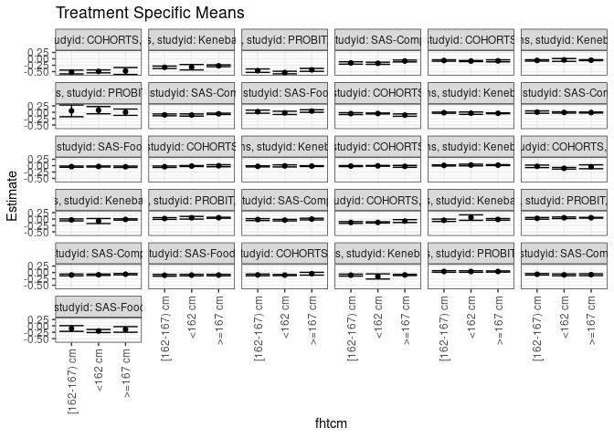

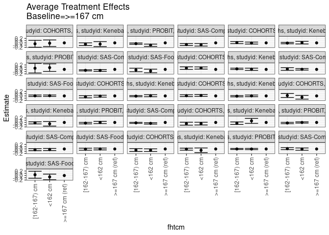

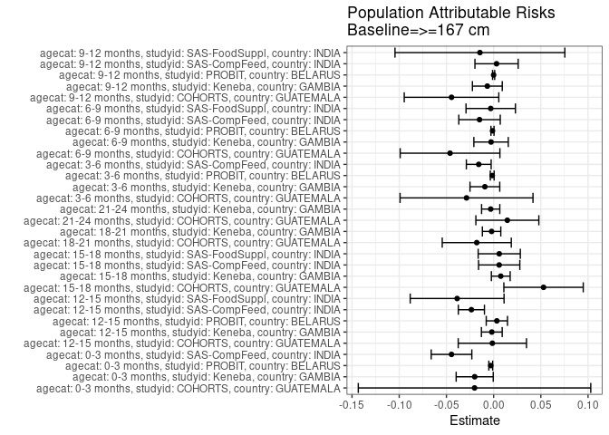

## Results Table

### Parameter: TSM

| agecat | studyid | country | intervention_level | baseline_level | estimate | ci_lower | ci_upper |
| --- | --- | --- | --- | --- | --- | --- | --- |
| 0-3 months | COHORTS | GUATEMALA | >=167 cm | NA | -0.4754364 | -0.6109850 | -0.3398878 |
| 0-3 months | COHORTS | GUATEMALA | <162 cm | NA | -0.4909998 | -0.5477969 | -0.4342027 |
| 0-3 months | COHORTS | GUATEMALA | [162-167) cm | NA | -0.5161084 | -0.5904104 | -0.4418064 |
| 0-3 months | Keneba | GAMBIA | >=167 cm | NA | -0.2725020 | -0.3077510 | -0.2372530 |
| 0-3 months | Keneba | GAMBIA | <162 cm | NA | -0.3275281 | -0.4334342 | -0.2216221 |
| 0-3 months | Keneba | GAMBIA | [162-167) cm | NA | -0.3312793 | -0.3792425 | -0.2833161 |
| 0-3 months | PROBIT | BELARUS | >=167 cm | NA | -0.4309358 | -0.4886825 | -0.3731891 |
| 0-3 months | PROBIT | BELARUS | <162 cm | NA | -0.5370766 | -0.5873911 | -0.4867621 |
| 0-3 months | PROBIT | BELARUS | [162-167) cm | NA | -0.4638768 | -0.5321312 | -0.3956225 |
| 0-3 months | SAS-CompFeed | INDIA | >=167 cm | NA | -0.0847022 | -0.1205637 | -0.0488408 |
| 0-3 months | SAS-CompFeed | INDIA | <162 cm | NA | -0.1725010 | -0.2134403 | -0.1315617 |
| 0-3 months | SAS-CompFeed | INDIA | [162-167) cm | NA | -0.1602271 | -0.2071965 | -0.1132577 |
| 3-6 months | COHORTS | GUATEMALA | >=167 cm | NA | -0.0438737 | -0.1209529 | 0.0332055 |
| 3-6 months | COHORTS | GUATEMALA | <162 cm | NA | -0.1039207 | -0.1374128 | -0.0704287 |
| 3-6 months | COHORTS | GUATEMALA | [162-167) cm | NA | -0.0255358 | -0.0740817 | 0.0230102 |
| 3-6 months | Keneba | GAMBIA | >=167 cm | NA | -0.0150521 | -0.0404454 | 0.0103411 |
| 3-6 months | Keneba | GAMBIA | <162 cm | NA | -0.0762347 | -0.1744078 | 0.0219384 |
| 3-6 months | Keneba | GAMBIA | [162-167) cm | NA | -0.0326117 | -0.0716051 | 0.0063818 |
| 3-6 months | PROBIT | BELARUS | >=167 cm | NA | 0.0511031 | 0.0318587 | 0.0703475 |
| 3-6 months | PROBIT | BELARUS | <162 cm | NA | 0.0504874 | -0.0020246 | 0.1029995 |
| 3-6 months | PROBIT | BELARUS | [162-167) cm | NA | 0.0211827 | -0.0131298 | 0.0554952 |
| 3-6 months | SAS-CompFeed | INDIA | >=167 cm | NA | -0.0014411 | -0.0347557 | 0.0318735 |
| 3-6 months | SAS-CompFeed | INDIA | <162 cm | NA | -0.0426204 | -0.0727132 | -0.0125275 |
| 3-6 months | SAS-CompFeed | INDIA | [162-167) cm | NA | -0.0192522 | -0.0569095 | 0.0184051 |
| 6-9 months | COHORTS | GUATEMALA | >=167 cm | NA | -0.0788486 | -0.1356594 | -0.0220378 |
| 6-9 months | COHORTS | GUATEMALA | <162 cm | NA | -0.1309323 | -0.1565414 | -0.1053232 |
| 6-9 months | COHORTS | GUATEMALA | [162-167) cm | NA | -0.1334582 | -0.1674500 | -0.0994663 |
| 6-9 months | Keneba | GAMBIA | >=167 cm | NA | -0.0135383 | -0.0460095 | 0.0189329 |
| 6-9 months | Keneba | GAMBIA | <162 cm | NA | 0.0576084 | -0.0503051 | 0.1655218 |
| 6-9 months | Keneba | GAMBIA | [162-167) cm | NA | -0.0467241 | -0.0928803 | -0.0005678 |

[output cut: 63 more lines]

### Parameter: E(Y)

| agecat | studyid | country | intervention_level | baseline_level | estimate | ci_lower | ci_upper |
| --- | --- | --- | --- | --- | --- | --- | --- |
| 0-3 months | COHORTS | GUATEMALA | NA | NA | -0.4956734 | -0.5391037 | -0.4522430 |
| 0-3 months | Keneba | GAMBIA | NA | NA | -0.2925541 | -0.3202623 | -0.2648459 |
| 0-3 months | PROBIT | BELARUS | NA | NA | -0.4339788 | -0.4920905 | -0.3758672 |
| 0-3 months | SAS-CompFeed | INDIA | NA | NA | -0.1293116 | -0.1570838 | -0.1015393 |
| 3-6 months | COHORTS | GUATEMALA | NA | NA | -0.0725836 | -0.0990295 | -0.0461377 |
| 3-6 months | Keneba | GAMBIA | NA | NA | -0.0243287 | -0.0453184 | -0.0033389 |
| 3-6 months | PROBIT | BELARUS | NA | NA | 0.0496085 | 0.0303789 | 0.0688381 |
| 3-6 months | SAS-CompFeed | INDIA | NA | NA | -0.0172047 | -0.0462110 | 0.0118016 |
| 6-9 months | COHORTS | GUATEMALA | NA | NA | -0.1250180 | -0.1444785 | -0.1055575 |
| 6-9 months | Keneba | GAMBIA | NA | NA | -0.0162599 | -0.0424084 | 0.0098886 |
| 6-9 months | PROBIT | BELARUS | NA | NA | 0.0501252 | 0.0364772 | 0.0637733 |
| 6-9 months | SAS-CompFeed | INDIA | NA | NA | -0.0826792 | -0.0976756 | -0.0676829 |
| 6-9 months | SAS-FoodSuppl | INDIA | NA | NA | -0.1060840 | -0.1243061 | -0.0878619 |
| 9-12 months | COHORTS | GUATEMALA | NA | NA | -0.0937525 | -0.1108820 | -0.0766229 |
| 9-12 months | Keneba | GAMBIA | NA | NA | -0.1043948 | -0.1248389 | -0.0839507 |
| 9-12 months | PROBIT | BELARUS | NA | NA | 0.0380200 | 0.0165057 | 0.0595343 |
| 9-12 months | SAS-CompFeed | INDIA | NA | NA | -0.0844546 | -0.1064588 | -0.0624505 |
| 9-12 months | SAS-FoodSuppl | INDIA | NA | NA | -0.1543023 | -0.2067725 | -0.1018321 |
| 12-15 months | COHORTS | GUATEMALA | NA | NA | -0.0795786 | -0.0954422 | -0.0637150 |
| 12-15 months | Keneba | GAMBIA | NA | NA | -0.0546831 | -0.0687903 | -0.0405758 |
| 12-15 months | PROBIT | BELARUS | NA | NA | 0.0049023 | -0.1173760 | 0.1271806 |
| 12-15 months | SAS-CompFeed | INDIA | NA | NA | -0.0852063 | -0.1134490 | -0.0569636 |
| 12-15 months | SAS-FoodSuppl | INDIA | NA | NA | 0.0086211 | -0.0272082 | 0.0444504 |
| 15-18 months | COHORTS | GUATEMALA | NA | NA | -0.0589223 | -0.0748896 | -0.0429550 |
| 15-18 months | Keneba | GAMBIA | NA | NA | -0.0340694 | -0.0467538 | -0.0213851 |
| 15-18 months | SAS-CompFeed | INDIA | NA | NA | -0.0056259 | -0.0184980 | 0.0072462 |
| 15-18 months | SAS-FoodSuppl | INDIA | NA | NA | -0.0372612 | -0.0503965 | -0.0241260 |
| 18-21 months | COHORTS | GUATEMALA | NA | NA | -0.0212869 | -0.0355114 | -0.0070623 |
| 18-21 months | Keneba | GAMBIA | NA | NA | -0.0200780 | -0.0325402 | -0.0076159 |
| 21-24 months | COHORTS | GUATEMALA | NA | NA | -0.0126815 | -0.0238129 | -0.0015501 |
| 21-24 months | Keneba | GAMBIA | NA | NA | 0.0182744 | 0.0054117 | 0.0311371 |

### Parameter: ATE

| agecat | studyid | country | intervention_level | baseline_level | estimate | ci_lower | ci_upper |
| --- | --- | --- | --- | --- | --- | --- | --- |
| 0-3 months | COHORTS | GUATEMALA | >=167 cm | >=167 cm | 0.0000000 | 0.0000000 | 0.0000000 |
| 0-3 months | COHORTS | GUATEMALA | <162 cm | >=167 cm | -0.0155634 | -0.1625305 | 0.1314037 |
| 0-3 months | COHORTS | GUATEMALA | [162-167) cm | >=167 cm | -0.0406720 | -0.1952496 | 0.1139055 |
| 0-3 months | Keneba | GAMBIA | >=167 cm | >=167 cm | 0.0000000 | 0.0000000 | 0.0000000 |
| 0-3 months | Keneba | GAMBIA | <162 cm | >=167 cm | -0.0550261 | -0.1666442 | 0.0565919 |
| 0-3 months | Keneba | GAMBIA | [162-167) cm | >=167 cm | -0.0587773 | -0.1183001 | 0.0007455 |
| 0-3 months | PROBIT | BELARUS | >=167 cm | >=167 cm | 0.0000000 | 0.0000000 | 0.0000000 |
| 0-3 months | PROBIT | BELARUS | <162 cm | >=167 cm | -0.1061408 | -0.1564453 | -0.0558364 |
| 0-3 months | PROBIT | BELARUS | [162-167) cm | >=167 cm | -0.0329411 | -0.0623743 | -0.0035079 |
| 0-3 months | SAS-CompFeed | INDIA | >=167 cm | >=167 cm | 0.0000000 | 0.0000000 | 0.0000000 |
| 0-3 months | SAS-CompFeed | INDIA | <162 cm | >=167 cm | -0.0877987 | -0.1440090 | -0.0315885 |
| 0-3 months | SAS-CompFeed | INDIA | [162-167) cm | >=167 cm | -0.0755249 | -0.1195454 | -0.0315044 |
| 3-6 months | COHORTS | GUATEMALA | >=167 cm | >=167 cm | 0.0000000 | 0.0000000 | 0.0000000 |
| 3-6 months | COHORTS | GUATEMALA | <162 cm | >=167 cm | -0.0600471 | -0.1440882 | 0.0239941 |
| 3-6 months | COHORTS | GUATEMALA | [162-167) cm | >=167 cm | 0.0183379 | -0.0727549 | 0.1094308 |
| 3-6 months | Keneba | GAMBIA | >=167 cm | >=167 cm | 0.0000000 | 0.0000000 | 0.0000000 |
| 3-6 months | Keneba | GAMBIA | <162 cm | >=167 cm | -0.0611826 | -0.1625866 | 0.0402215 |
| 3-6 months | Keneba | GAMBIA | [162-167) cm | >=167 cm | -0.0175595 | -0.0640924 | 0.0289734 |
| 3-6 months | PROBIT | BELARUS | >=167 cm | >=167 cm | 0.0000000 | 0.0000000 | 0.0000000 |
| 3-6 months | PROBIT | BELARUS | <162 cm | >=167 cm | -0.0006156 | -0.0504408 | 0.0492095 |
| 3-6 months | PROBIT | BELARUS | [162-167) cm | >=167 cm | -0.0299204 | -0.0627228 | 0.0028821 |
| 3-6 months | SAS-CompFeed | INDIA | >=167 cm | >=167 cm | 0.0000000 | 0.0000000 | 0.0000000 |
| 3-6 months | SAS-CompFeed | INDIA | <162 cm | >=167 cm | -0.0411792 | -0.0720410 | -0.0103175 |
| 3-6 months | SAS-CompFeed | INDIA | [162-167) cm | >=167 cm | -0.0178111 | -0.0420517 | 0.0064296 |
| 6-9 months | COHORTS | GUATEMALA | >=167 cm | >=167 cm | 0.0000000 | 0.0000000 | 0.0000000 |
| 6-9 months | COHORTS | GUATEMALA | <162 cm | >=167 cm | -0.0520838 | -0.1143998 | 0.0102323 |
| 6-9 months | COHORTS | GUATEMALA | [162-167) cm | >=167 cm | -0.0546096 | -0.1208131 | 0.0115940 |
| 6-9 months | Keneba | GAMBIA | >=167 cm | >=167 cm | 0.0000000 | 0.0000000 | 0.0000000 |
| 6-9 months | Keneba | GAMBIA | <162 cm | >=167 cm | 0.0711467 | -0.0415462 | 0.1838396 |
| 6-9 months | Keneba | GAMBIA | [162-167) cm | >=167 cm | -0.0331858 | -0.0896196 | 0.0232480 |

[output cut: 63 more lines]

### Parameter: PAR

| agecat | studyid | country | intervention_level | baseline_level | estimate | ci_lower | ci_upper |
| --- | --- | --- | --- | --- | --- | --- | --- |
| 0-3 months | COHORTS | GUATEMALA | >=167 cm | NA | -0.0202369 | -0.1433462 | 0.1028723 |
| 0-3 months | Keneba | GAMBIA | >=167 cm | NA | -0.0200521 | -0.0396822 | -0.0004220 |
| 0-3 months | PROBIT | BELARUS | >=167 cm | NA | -0.0030431 | -0.0050735 | -0.0010127 |
| 0-3 months | SAS-CompFeed | INDIA | >=167 cm | NA | -0.0446093 | -0.0661248 | -0.0230938 |
| 3-6 months | COHORTS | GUATEMALA | >=167 cm | NA | -0.0287099 | -0.0991095 | 0.0416897 |
| 3-6 months | Keneba | GAMBIA | >=167 cm | NA | -0.0092765 | -0.0250382 | 0.0064851 |
| 3-6 months | PROBIT | BELARUS | >=167 cm | NA | -0.0014946 | -0.0035359 | 0.0005468 |
| 3-6 months | SAS-CompFeed | INDIA | >=167 cm | NA | -0.0157636 | -0.0288918 | -0.0026354 |
| 6-9 months | COHORTS | GUATEMALA | >=167 cm | NA | -0.0461694 | -0.0989788 | 0.0066400 |
| 6-9 months | Keneba | GAMBIA | >=167 cm | NA | -0.0027216 | -0.0209503 | 0.0155070 |
| 6-9 months | PROBIT | BELARUS | >=167 cm | NA | -0.0012001 | -0.0028276 | 0.0004274 |
| 6-9 months | SAS-CompFeed | INDIA | >=167 cm | NA | -0.0149324 | -0.0368742 | 0.0070093 |
| 6-9 months | SAS-FoodSuppl | INDIA | >=167 cm | NA | -0.0030852 | -0.0292462 | 0.0230757 |
| 9-12 months | COHORTS | GUATEMALA | >=167 cm | NA | -0.0445981 | -0.0946732 | 0.0054770 |
| 9-12 months | Keneba | GAMBIA | >=167 cm | NA | -0.0066682 | -0.0224706 | 0.0091342 |
| 9-12 months | PROBIT | BELARUS | >=167 cm | NA | -0.0000187 | -0.0011309 | 0.0010935 |
| 9-12 months | SAS-CompFeed | INDIA | >=167 cm | NA | 0.0031032 | -0.0198053 | 0.0260118 |
| 9-12 months | SAS-FoodSuppl | INDIA | >=167 cm | NA | -0.0145112 | -0.1044749 | 0.0754525 |
| 12-15 months | COHORTS | GUATEMALA | >=167 cm | NA | -0.0013535 | -0.0375147 | 0.0348076 |
| 12-15 months | Keneba | GAMBIA | >=167 cm | NA | -0.0019478 | -0.0129490 | 0.0090535 |
| 12-15 months | PROBIT | BELARUS | >=167 cm | NA | 0.0034193 | -0.0078446 | 0.0146833 |
| 12-15 months | SAS-CompFeed | INDIA | >=167 cm | NA | -0.0235504 | -0.0373686 | -0.0097321 |
| 12-15 months | SAS-FoodSuppl | INDIA | >=167 cm | NA | -0.0386669 | -0.0883685 | 0.0110348 |
| 15-18 months | COHORTS | GUATEMALA | >=167 cm | NA | 0.0528735 | 0.0108253 | 0.0949217 |
| 15-18 months | Keneba | GAMBIA | >=167 cm | NA | 0.0075515 | -0.0023988 | 0.0175017 |
| 15-18 months | SAS-CompFeed | INDIA | >=167 cm | NA | 0.0058799 | -0.0159707 | 0.0277305 |
| 15-18 months | SAS-FoodSuppl | INDIA | >=167 cm | NA | 0.0059453 | -0.0163741 | 0.0282646 |
| 18-21 months | COHORTS | GUATEMALA | >=167 cm | NA | -0.0178789 | -0.0544497 | 0.0186919 |
| 18-21 months | Keneba | GAMBIA | >=167 cm | NA | -0.0021626 | -0.0119194 | 0.0075942 |
| 21-24 months | COHORTS | GUATEMALA | >=167 cm | NA | 0.0145303 | -0.0188226 | 0.0478832 |
| 21-24 months | Keneba | GAMBIA | >=167 cm | NA | -0.0031096 | -0.0127468 | 0.0065275 |